# Lecture 4: Distribution of RVs

Jesus Avalos

2024-02-04

In this lab we’ll investigate the probability distribution that is most central to statistics:

The normal distribution. If we are confident that our data are nearly normal, that opens the door to many powerful statistical methods. Here we’ll use the graphical tools of R to assess the normality of our data and also learn how to generate random numbers from a normal distribution.

### The Data

This week we’ll be working with measurements of body dimensions. This data set contains measurements from 247 men and 260 women, ost of whom were considered healthy young adults.

We begin by downloading the dataset from *[openintro.org](https://www.openintro.org/book/statdata/index.php?data=bdims)*, and loading it intro our R workspace:

```r
# Download dataset from its source:
download.file("http://www.openintro.org/stat/data/bdims.RData", destfile = "bdims.RData")

# Load the data in R
load("bdims.RData")
```

Let’s take a quick peek at the first few rows of the data.

```r
# See the first rows of the data
head(bdims)
```

```
##   bia.di bii.di bit.di che.de che.di elb.di wri.di kne.di ank.di sho.gi che.gi
## 1   42.9   26.0   31.5   17.7   28.0   13.1   10.4   18.8   14.1  106.2   89.5
## 2   43.7   28.5   33.5   16.9   30.8   14.0   11.8   20.6   15.1  110.5   97.0
## 3   40.1   28.2   33.3   20.9   31.7   13.9   10.9   19.7   14.1  115.1   97.5
## 4   44.3   29.9   34.0   18.4   28.2   13.9   11.2   20.9   15.0  104.5   97.0
## 5   42.5   29.9   34.0   21.5   29.4   15.2   11.6   20.7   14.9  107.5   97.5
## 6   43.3   27.0   31.5   19.6   31.3   14.0   11.5   18.8   13.9  119.8   99.9
##   wai.gi nav.gi hip.gi thi.gi bic.gi for.gi kne.gi cal.gi ank.gi wri.gi age
## 1   71.5   74.5   93.5   51.5   32.5   26.0   34.5   36.5   23.5   16.5  21
## 2   79.0   86.5   94.8   51.5   34.4   28.0   36.5   37.5   24.5   17.0  23
## 3   83.2   82.9   95.0   57.3   33.4   28.8   37.0   37.3   21.9   16.9  28
## 4   77.8   78.8   94.0   53.0   31.0   26.2   37.0   34.8   23.0   16.6  23
## 5   80.0   82.5   98.5   55.4   32.0   28.4   37.7   38.6   24.4   18.0  22
## 6   82.5   80.1   95.3   57.5   33.0   28.0   36.6   36.1   23.5   16.9  21
##    wgt   hgt sex
## 1 65.6 174.0   1
## 2 71.8 175.3   1
## 3 80.7 193.5   1
## 4 72.6 186.5   1
## 5 78.8 187.2   1
## 6 74.8 181.5   1
```

You’ll see that for every observation we have 25 measurements, many of which are either diameters or girths.

A key to the variable names can be found at *[openintro.org](https://http://www.openintro.org/stat/data/bdims.php)*, but we’ll be focusing on just three columns to get started: weight in kg (wgt), height in cm (hgt), and sex (1 indicates male, 0 indicates female).

Since males and females tend to have different body dimensions, it will be useful to create two additional data sets:

One with only men and another with only women.

```r
# Body dimensions by sex
mdims <- subset(bdims, sex == 1)
fdims <- subset(bdims, sex == 0)
```

#### 1. Make a histogram of men’s heights and a histogram of women’s heights. How would you compare the various aspects of the two distributions?

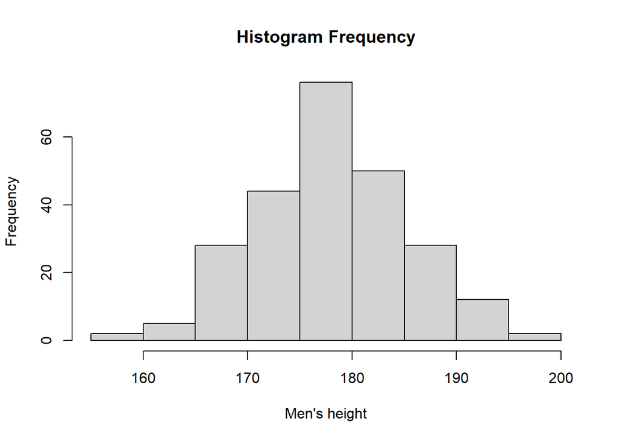

```r
# Histogram of men's heights
hist(mdims$hgt, main = "Histogram Frequency", xlab = "Men's height")
```

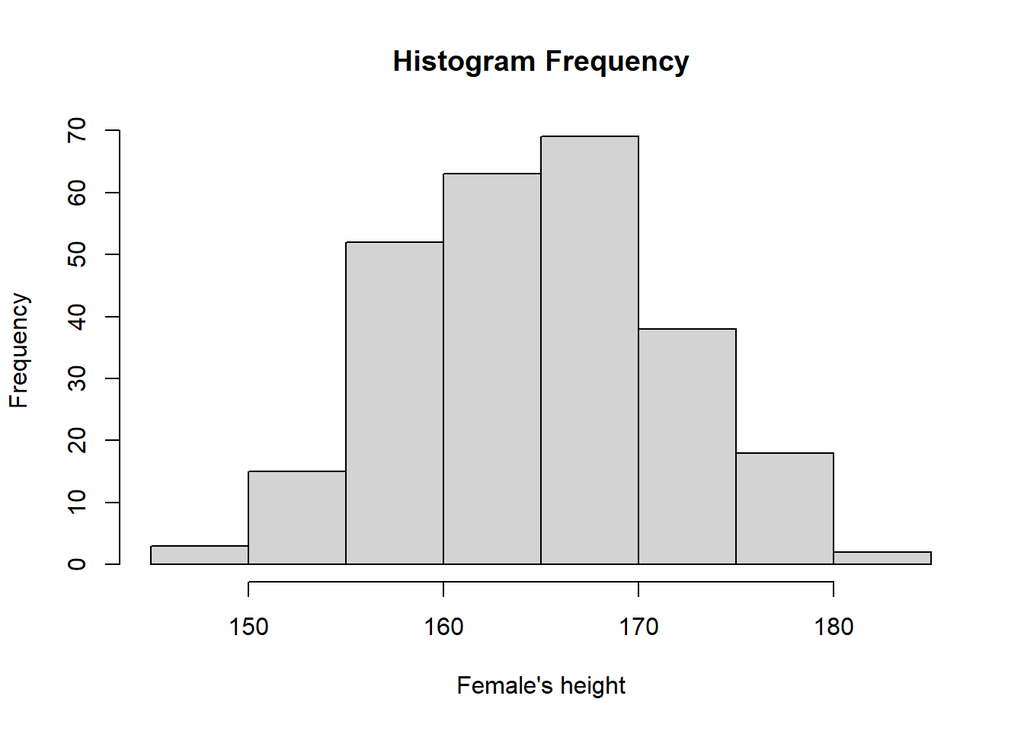

```r
# Histogram of women's heights
hist(fdims$hgt, main = "Histogram Frequency", xlab = "Female's height")
```

*Both distributions are unimodal and don’t seem to have long tails but look symmetrical instead. We may also see that, comparing the tallest bars in both charts, we see that the most frequent height for men is 175cm, while for women is 165cm*

### The Normal Distribution

In your description of the distributions, did you use words like bell-shaped or mormal?

It’s tempting to say so when faced with a unimodal symmetric distribution.

To see how accurate that description is, we can plot a normal distribution curve on top of a histogram to see how closely the data follow a normal distribution. This normal curve should have the same mean and standard deviation as the data. We’ll be working with women’s heights, so let’s sotre them as a separate object and then calculate some statistics that will be referenced later.

```r
# Mean of Female Height
fhgtmean <- mean(fdims$hgt)

# StdDev of Female Height
fhgtsd <- sd(fdims$hgt)
```

Next, we make a density histogram to use as the backdrop and use the lines function to overlay a normal probability curve.

**The difference between a frequency histogram and a density histogram is that while in a frequency histogram the heights of the bars add up to the total number of observations, in a density histogram the areas of the bars add up to 1.** The area of each bar can be calculated as simply as the height times the width of the bar. Using a density histogram allows us to properly overlay a normal distribution curve over the histogram since the curve is a normal probability density function. **Frequency and density histograms both display the same exact shape**; they only differ in their y-axis. You can verify this by comparing the frequency histogram you constructed earlier and the density histogram created by the commands below:

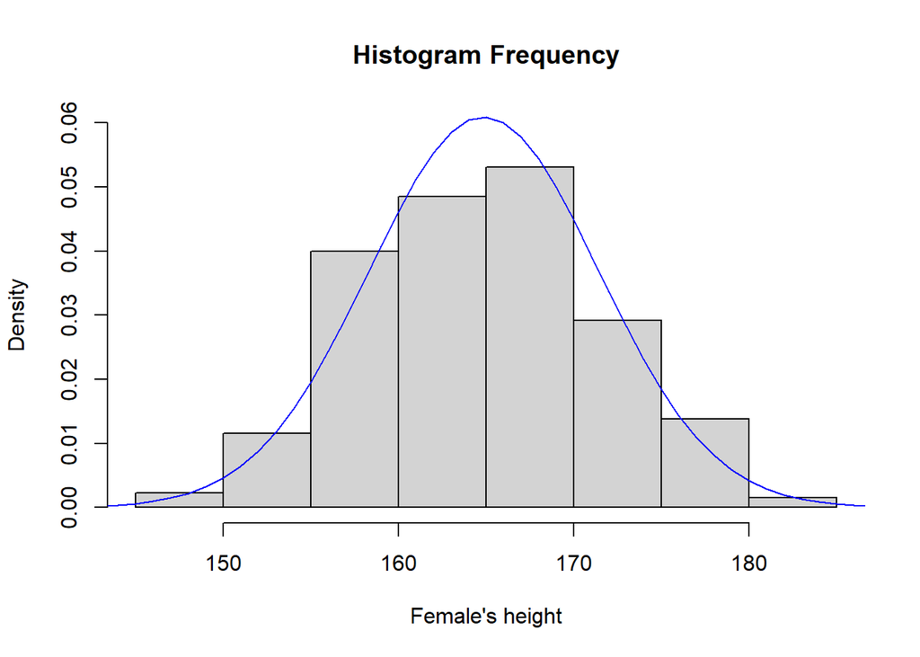

```r
#hist(fdims$hgt)

hist(fdims$hgt, probability = TRUE, ylim = c(0, 0.06), main = "Histogram Frequency", xlab = "Female's height")
x <- 140:190
y <- dnorm(x = x, mean = fhgtmean, sd = fhgtsd)
lines(x = x, y = y, col = "blue")
```

**Explanation of the above statements for plotting:**

After plotting the density histogram with the first command, we create the x- and y-coordinates for the normal curve.

We chose the x range as 140 to 190 in order to span the entire range of fheight.

To create y, we use dnorm to calculate the density of each of those x-values in a distribution that is normal with mean fhgtmean and standard deviation fhgtsd. The final command draws a curve on the existing plot (the density histogram) by connecting each of the points specified by x and y. The argument col simply sets the color for the line to be drawn. If we left it out, the line would be drawn in black.

To adjust the y-axis you can add a third argument to the histogram function: ylim = c(0, 0.06). Try this for your self:

#### 2. Based on this plot, does it appear that the data follow a nearly normal distribution?

*Yes, it does follow a nearly normal distribution. We may see that de frequency histogram is unimodal and the mode is near the mean. We may notice that the density histogram has a bell-shaped distribution, as well as symmetric.*

### Evaluating the normal distribution

Eyeballing the shape of the histogram is one way to determine if the data appear to be nearly normally distributed but it can be frustrating to decide just how close the histogram is to the curve. An alternative approach involves constructing a normal probability plot, also called a normal Q-Q plot for “quantile-quantile”.

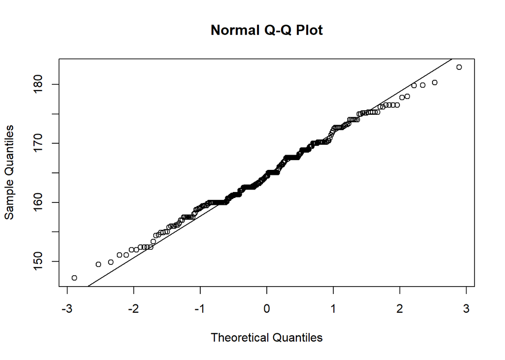

```r
# Normal probability plot - Normal Q-Q plot
qqnorm(fdims$hgt)
qqline(fdims$hgt)
```

A data set that is nearly normal will result in a probability plot where the points closely follow the line. Any deviations from normality leads to deviations of these points from the line. The plot for femaile heights shows points that tend to follow the line but with some errant points towards the tails. We’re left with the same problem that we ecountered with the histogram above: how close is close enough?

A useful way to address this question is to rephrase it as: what do probability plots look like for data that I know came from a normal distribution? We can answer this by simulating data from a normal distribution using rnorm.

```r
# Simulation of normal distribution
sim_norm <- rnorm(n = length(fdims$hgt), mean = fhgtmean, sd = fhgtsd)
```

The first argument indicates how many numbers you’d like to generate, which we specify to be the same number of heights in the fdims data set using the length function. The last two arguments determine the mean and standard deviation of the normal distribution from which the simulated sample will be generated. We can take a look at the shape of our simulated data set, sim_norm, as well as its normal probability plot.

#### 3. Make a normal probability plot of sim_norm. Do all of the points fall on the line? How does this plot compare to the probability plot for the real data?

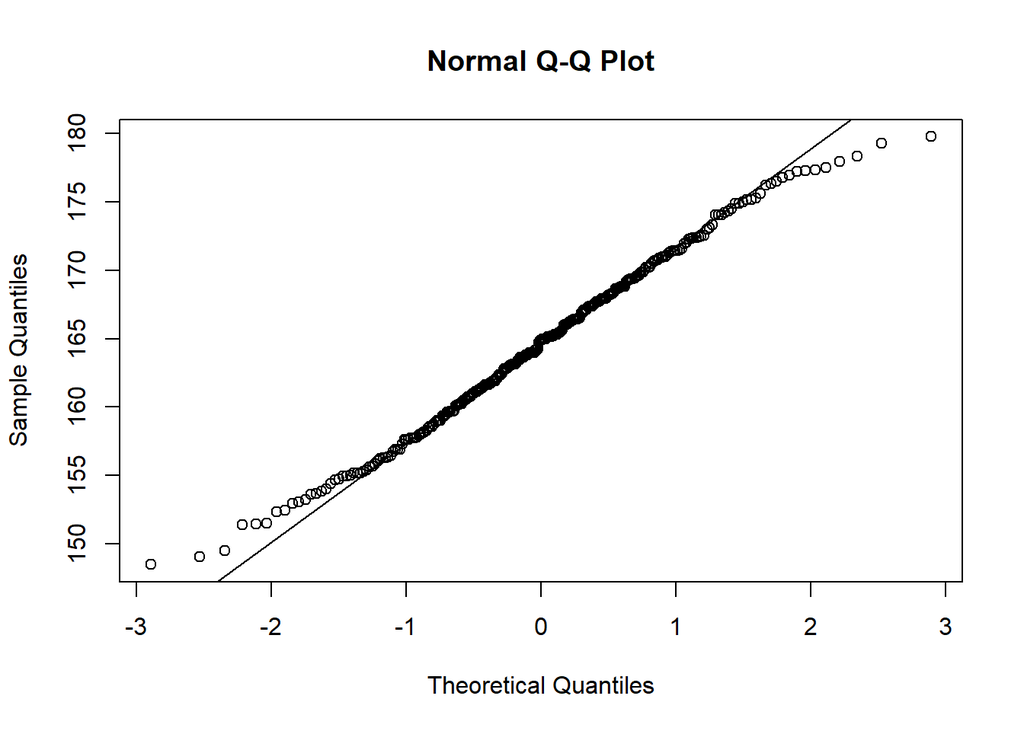

```r
qqnorm(sim_norm)
qqline(sim_norm)
```

Even better than comparing the original plot to a single plot generated from a normal distribution is to compare it to many more plots using the following function. It may be helpful to click the zoom button in the plot window.

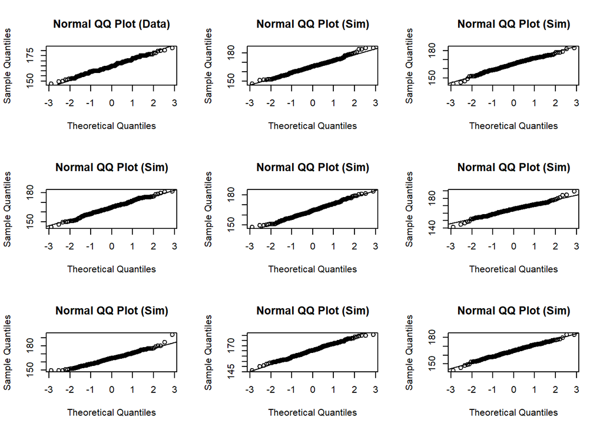

```r
qqnormsim(fdims$hgt)
```

#### 4. Does the normal probability plot for fdims$hgt look similar to the plots created for the simulated data sim_norm? That is, do plots provide evidence that the female heights are nearly normal?

*Yes they do. Q-Q plots from the female heights data show their points near the line, which is a sign for normal probability. A few points at the tails look slightly separated from the line.*

#### 5. Using the same technique, determine wheter or not female weights appear to come from a normal distribution.

[figure not shown]

```r
# Mean and StdDev of female's weights
fwgtmean <- mean(fdims$wgt)
fwgtsd <- sd(fdims$wgt)

# Histogram of female's weights
hist(fdims$wgt, main = "Histogram Frequency", xlab = "Female's height")
```

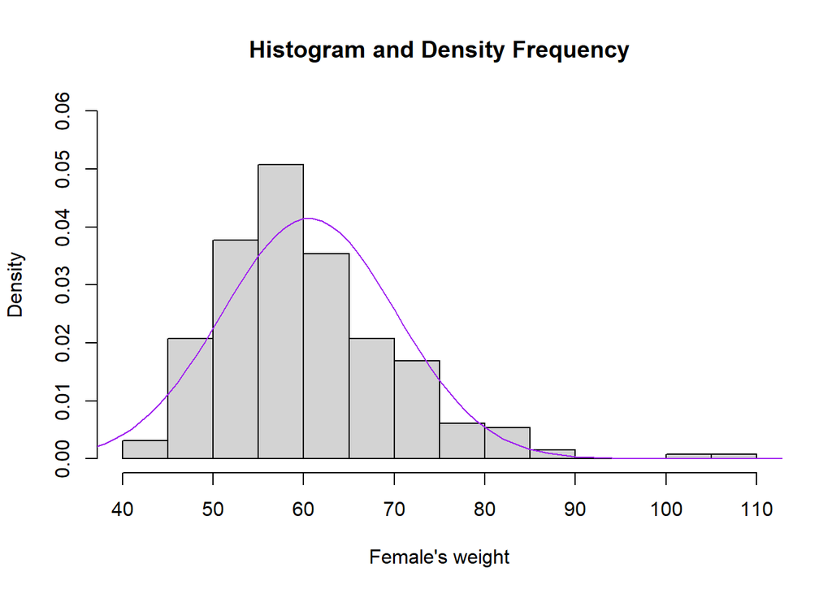

```r
# Histogram and density frequency of female's weights
hist(fdims$wgt, probability = TRUE, ylim = c(0, 0.06), main = "Histogram and Density Frequency", xlab = "Female's weight")
x <- min(fdims$wgt - 10):max(fdims$wgt + 10)
y <- dnorm(x = x, mean = fwgtmean, sd = fwgtsd)
lines(x = x, y = y, col = "purple")
```

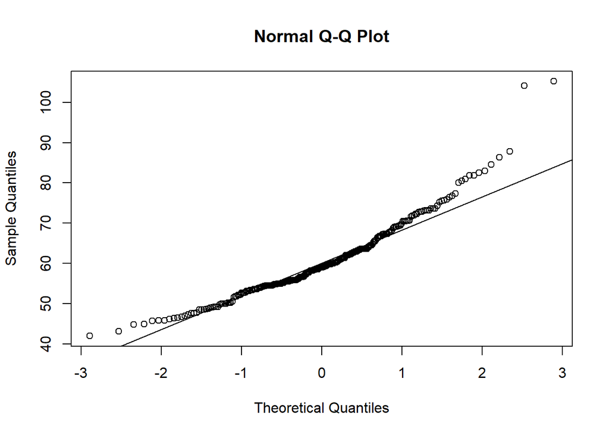

```r
# Normal Probability Plot - Normal Q-Q Plot
qqnorm(fdims$wgt)
qqline(fdims$wgt)
```

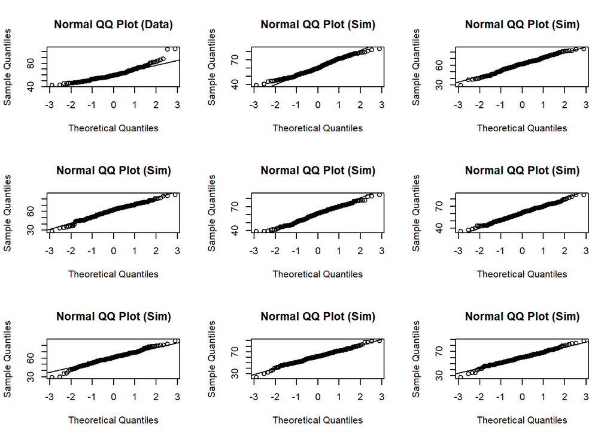

```r
# multiple normal QQ plots
qqnormsim(fdims$wgt)
```

*We may notice that the weight distribution for females is unimodal and has a long tail to the right (right-skewed). Based on the Normal Q-Q plot, we may conclude that the distribution is right-skewed since the points bend up and to the left of the line*

### Normal Probabilities

Okay, so now you have a slew of tools to judge whether or not a variable is normally distributed. Why should we care?

It turns out that statisticians know a lot about the normal distribution. Once we decide that random variable is approximately normal, we can answer all sorts of questions about that variable related to probability. Take, for example, the question of, “What is the probability that a randomly chosen young adult female is taller than 6 feet (about 182 cm)” (The study that published this data set is clear to point out that the sample was not random and therefore inference to a general population is not suggested. We do so here only as an exercise.)

So…

What is the probability that a randomly chosen young adult female is taller than 6 feet (about 182 cm)?

Le us draw the density plots again for illustration:

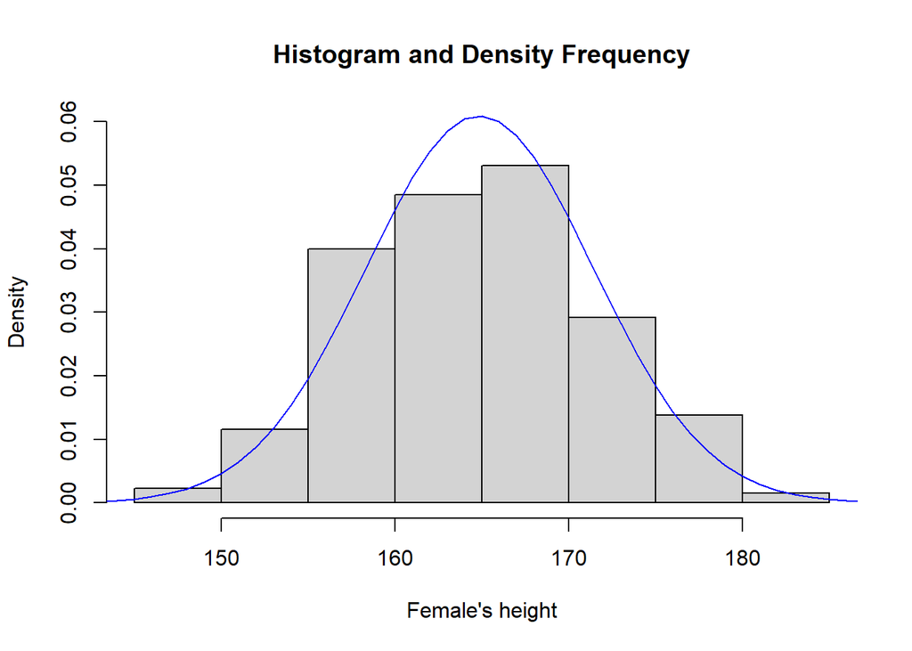

```r
hist(fdims$hgt, probability = TRUE, ylim = c(0,0.06), main = "Histogram and Density Frequency", xlab = "Female's height")
x <- 140:190
y <- dnorm(x=x, mean = fhgtmean, sd = fhgtsd)
lines(x=x, y=y, col = "blue")
```

If we assume that female heights are normally distributed (a very close approximation is also okay), we can find this probability by calculating a Z score and consulting a Z table (also called a normal probability table). In R, this is done in one step with the function pnorm.

```r
# Assume normal distribution
# Probability of a random female is taller than 182cm
1 - pnorm(q = 182, mean = fhgtmean, sd = fhgtsd)
```

```
## [1] 0.004434387
```

Note that the function pnorm gives the area under the normal curve below a given value, q, with a given mean and standard deviation.

Since we’re interested in the probability that someone is taller than 182 cm, we have to take one minus that probability.

Assuming a normal distribution has allowed us to calculate a theoretical probability.

If we want to calculate the probability empirically, we simply need to determine how many observations fall above 182 then divide this number by the total sample size.

```r
# Empirical probability
# Proportion of females with height above 182 cm
sum(fdims$hgt > 182) / length(fdims$hgt)
```

```
## [1] 0.003846154
```

Although the probabilities are not exactly the same, they are reasonably close. The closer that your distribution is to being normal, the more accurate the theoretical probabilities will be.

```r
# Probability that a female's height is over 173 cm
1 - pnorm(q=173, mean = fhgtmean, sd = fhgtsd)
```

```
## [1] 0.1071381
```

```r
# Empirical probability
sum(fdims$hgt > 173)/length(fdims$hgt)
```

```
## [1] 0.1192308
```

```r
# Probability that a female's height is over 155 but under 173 centimeters.
pnorm(q=173, mean = fhgtmean, sd = fhgtsd) - pnorm(q=155, mean = fhgtmean, sd = fhgtsd)
```

```
## [1] 0.8271442
```

```r
# Empirical probability
sum(fdims$hgt > 155 & fdims$hgt < 173)/length(fdims$hgt)
```

```
## [1] 0.8076923
```

### On your own

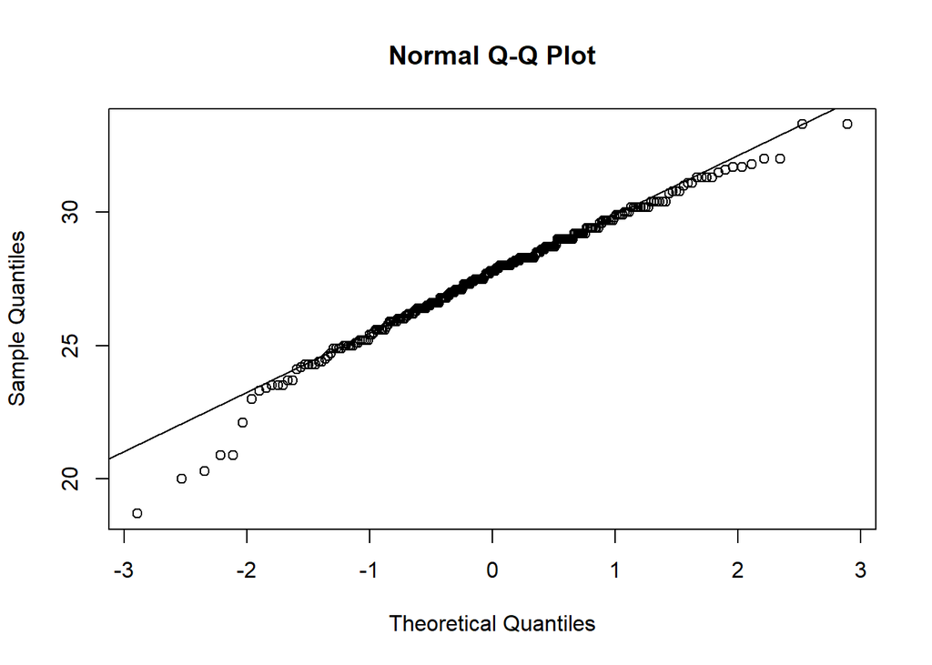

```r
# B
qqnorm(fdims$bii.di)
qqline(fdims$bii.di)
```

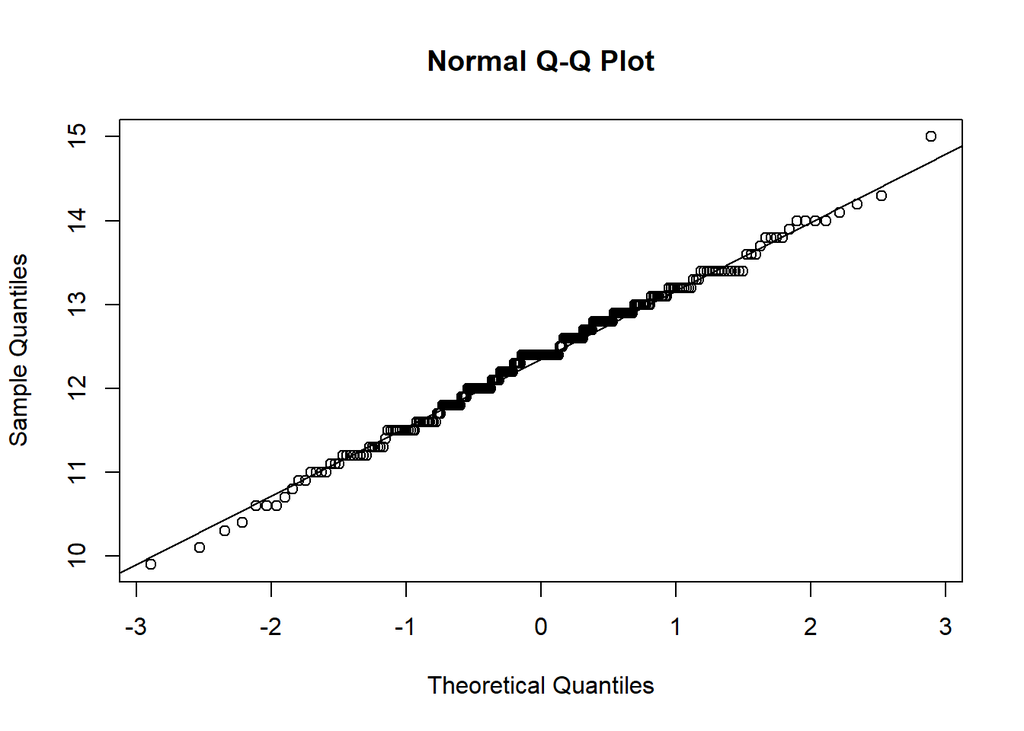

```r
# C
qqnorm(fdims$elb.di)
qqline(fdims$elb.di)
```

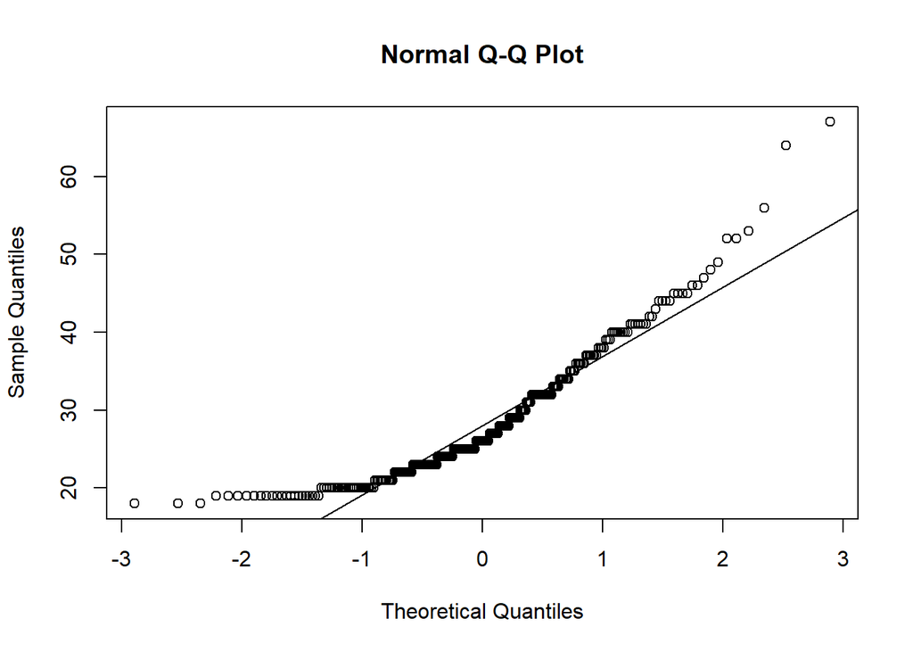

```r
# D
qqnorm(fdims$age)
qqline(fdims$age)
```

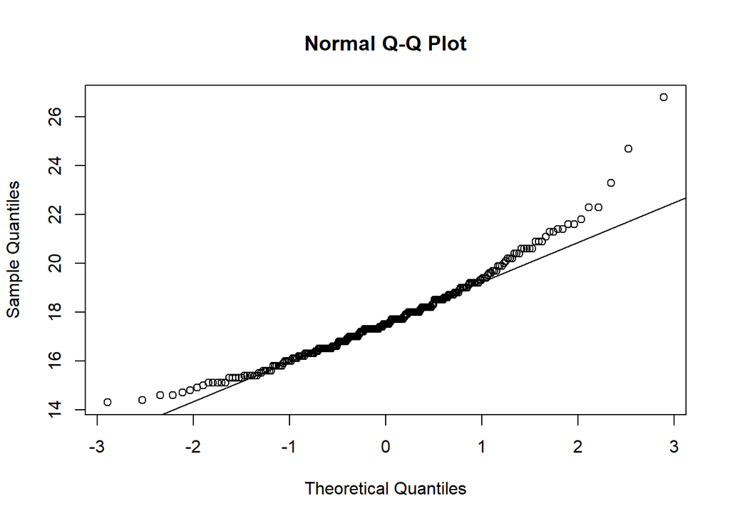

```r
# A
qqnorm(fdims$che.de)
qqline(fdims$che.de)
```